# TP Clustering

Data Analytics

Igor FIDALGO

November 28, 2019

## Exercise 1

Download the dataset: Ligue1 2017-2018 and import it into R. Put the argument row.names to 1.

```r
ligue1 <- read.csv("ligue1_17_18.csv", sep=";",header=T,row.names=1)
```

## Exercise 2

Print the first two rows of the dataset and the total number of features in this dataset.

```r
#print the first two lines of dataframe ligue1
head(ligue1,2)
```

```
##          Points Wins Draws Loses Goals.scored Goals.conceded Difference.goals
## Paris-SG     93   29     6     3          108             29               79
## Monaco       80   24     8     6           85             45               40
##          Points.per.game red.cards yellow.cards clean.sheets.percentage
## Paris-SG            2.45         6           66                      47
## Monaco              2.11         3           70                      37
##          failed.to.score.percentage shots.per.match.average
## Paris-SG                          8                   16.05
## Monaco                           11                   15.68
##          shots.on.goal.per.match.average ball.possession.per.game.average
## Paris-SG                            6.74                            63.34
## Monaco                              3.18                            57.68
##          sum.offside.in.attack sum.offside.in.defense corners.per.game.average
## Paris-SG                    98                     99                     6.71
## Monaco                      93                     90                     6.39
##          fouls.for.sum fouls.against.sum
## Paris-SG           139               105
## Monaco             115               112
```

```r
#total number of features
ncol(ligue1)
```

```
## [1] 20
```

## Exercise 3

We will first consider a smaller dataset to easily understand the results of k-means. Create a new dataset in which you consider only Points and Yellow.cards from the original dataset. Name it pointsCards

```r
library(dplyr)
pointCards <- ligue1 %>% select(Points, yellow.cards)
```

## Exercise 4

Apply k-means on pointsCards. Chose k=2 clusters and put the number of iterations to 20. Store your results into km. (Remark: kmeans() uses a random initialization of the clusters, so the results may vary from one call to another. Use set.seed() to have reproducible outputs).

```r
set.seed(28112019)
#run kmeans algorithms with 2 clusters and 20 iterations
km <- kmeans(pointCards,centers=2, iter.max = 20)
```

## Exercise 5

Print and describe what is inside km.

```r
print(km)
```

```
## K-means clustering with 2 clusters of sizes 4, 16
##
## Cluster means:
##   Points yellow.cards
## 1  82.00      71.2500
## 2  44.75      71.5625
##
## Clustering vector:
##      Paris-SG        Monaco          Lyon     Marseille        Rennes
##             1             1             1             1             2
##      Bordeaux Saint-Etienne          Nice        Nantes   Montpellier
##             2             2             2             2             2
##         Dijon      Guingamp        Amiens        Angers    Strasbourg
##             2             2             2             2             2
##          Caen         Lille      Toulouse        Troyes          Metz
##             2             2             2             2             2
##
## Within cluster sum of squares by cluster:
## [1]  256.750 2180.938
##  (between_SS / total_SS =  64.6 %)
##
## Available components:
##
## [1] "cluster"      "centers"      "totss"        "withinss"     "tot.withinss"
## [6] "betweenss"    "size"         "iter"         "ifault"
```

## Exercise 6

What are the coordinates of the centers of the clusters (called also prototypes or centroids) ?

```r
km$centers
```

```
##   Points yellow.cards
## 1  82.00      71.2500
## 2  44.75      71.5625
```

## Exercise 7

Plot the data (Yellow.cards vs Points). Color the points corresponding to their cluster.

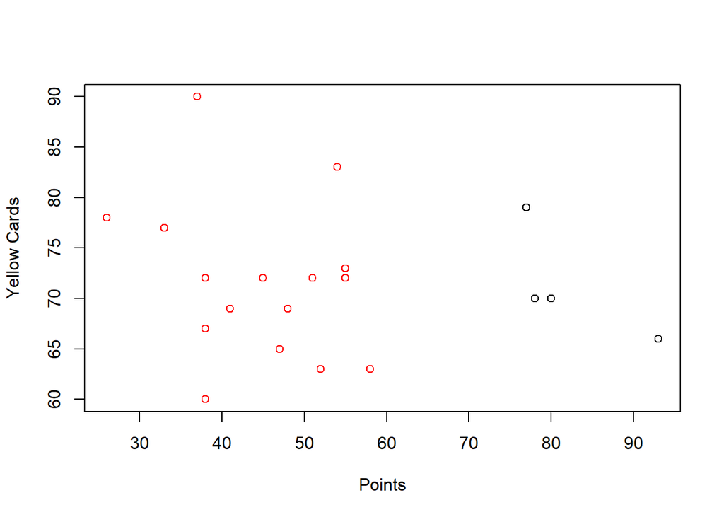

```r
plot(pointCards, col = km$cluster,xlab="Points",ylab="Yellow Cards")
```

## Exercise 8

Add to the previous plot the clusters centroids and add the names of the observations.

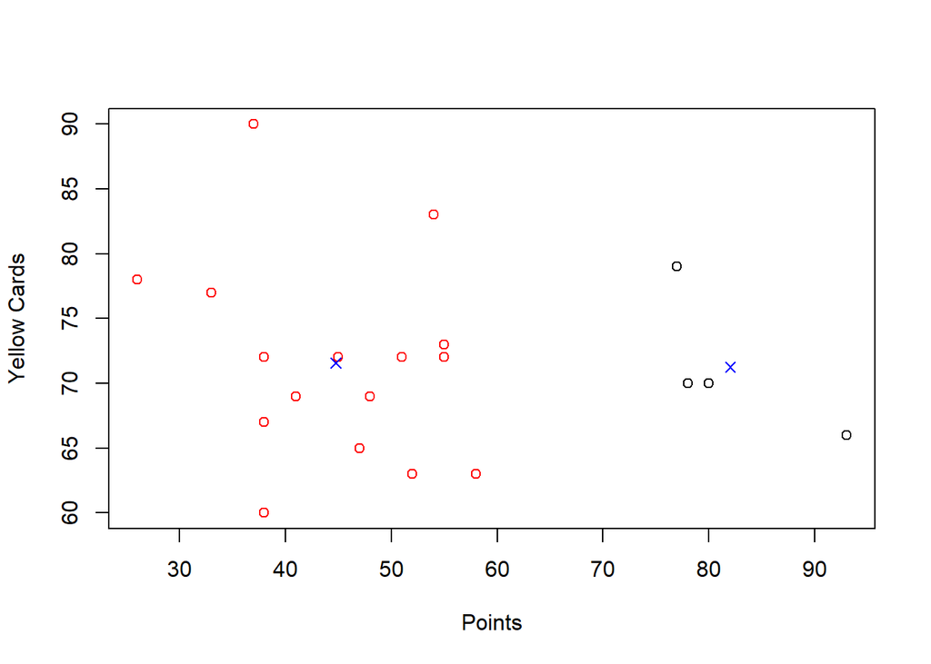

```r
plot(pointCards, col = km$cluster,xlab="Points",ylab="Yellow Cards")
points(km$centers, pch = 4, col="blue")
```

## Exercise 9

Re-run k-means on pointsCards using 3 and 4 clusters and store the results into km3 and km4 respectively. Visualize the results like in question 7 and 8.

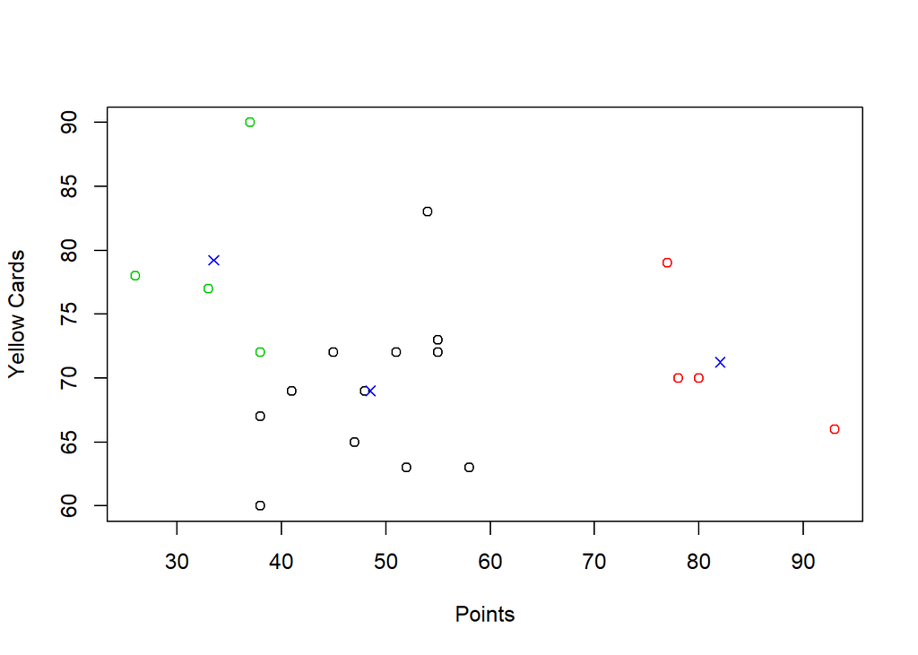

```r
km3 <- kmeans(pointCards,centers=3, iter.max = 20)
#plot new clusters
plot(pointCards, col = km3$cluster,xlab="Points",ylab="Yellow Cards")
points(km3$centers, pch = 4, col="blue")
```

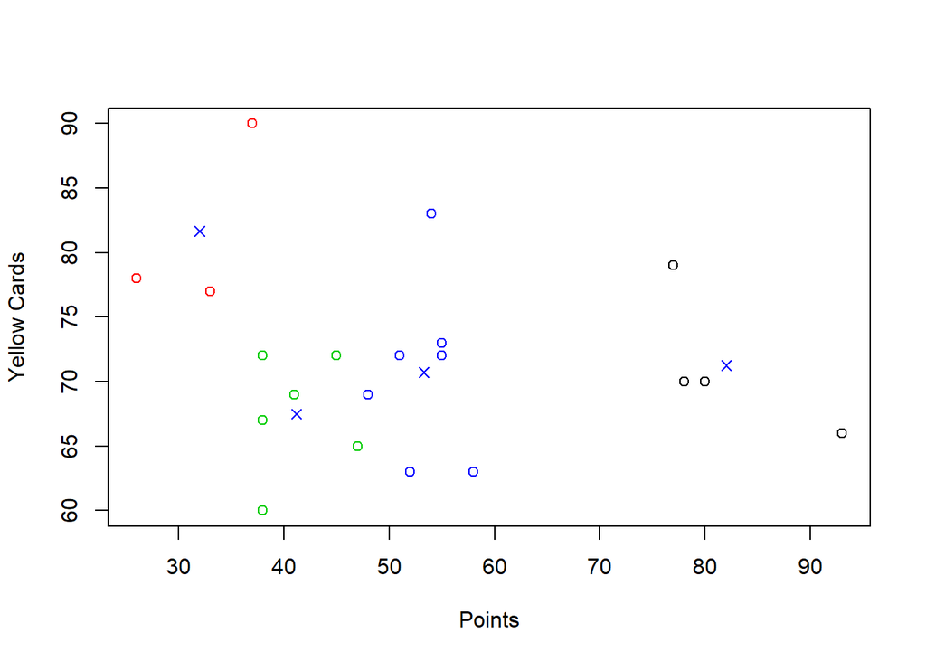

```r
#rerun kmeans with 3 and 4 clusters
km4 <- kmeans(pointCards,centers=4, iter.max = 20)
#plot new clusters
plot(pointCards, col = km4$cluster,xlab="Points",ylab="Yellow Cards")
points(km4$centers, pch = 4, col="blue")
```

## Exercise 10

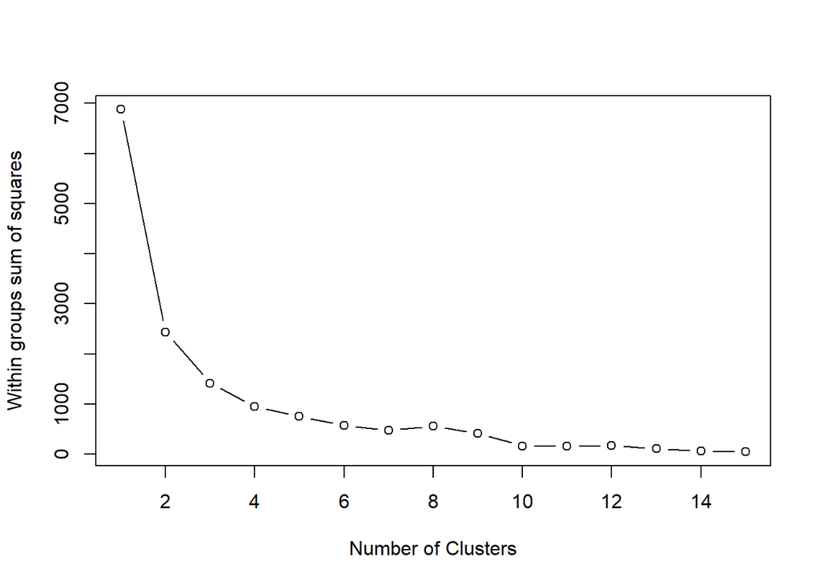

```r
mydata <- pointCards
wss <- (nrow(mydata)-1)*sum(apply(mydata,2,var))
for (i in 2:15) wss[i] <- sum(kmeans(mydata, centers=i)$withinss)
plot(1:15, wss, type="b", xlab="Number of Clusters",ylab="Within groups sum of squares")
```

## Exercise 11

Modify the code of the previous question in order to visualize the ‘between_SS / total_SS’. Interpret the results.

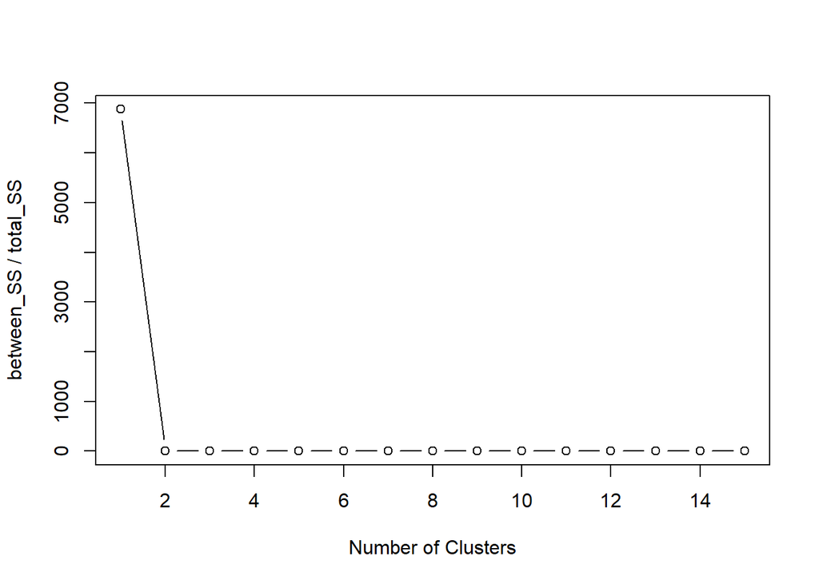

```r
mydata <- pointCards
wss <- (nrow(mydata)-1)*sum(apply(mydata,2,var))
for (i in 2:15) wss[i] <- (kmeans(mydata, centers=i)$betweenss / kmeans(mydata, centers=i)$totss)
plot(1:15, wss, type="b", xlab="Number of Clusters",ylab="between_SS / total_SS")
```

## Exercise 12

Scale the dataset and transform it to a data frame again. Store the scaled dataset into ligue1_scaled.

```r
ligue1_scaled <- as.data.frame(scale(ligue1))
```

## Exercise 13

Apply kmeans() on ligue1 and on ligue1_scaled using 3 clusters and 20 iterations. Store the results into km.ligue1 and km.ligue1.scaled respectively (do not forget to set a seed)

```r
set.seed(28112019)
km.ligue1 <- kmeans(ligue1,centers=3, iter.max = 20)
km.ligue1.scaled <- kmeans(ligue1_scaled,centers=3, iter.max = 20)
```

## Exercise 14

How many observations there are in each cluster of km.ligue1 and km.ligue1.scaled ? (you can use table()). Do you obtain the same results when you perform kmeans() on the scaled and unscaled data?

```r
table(km.ligue1$cluster)
```

```
##
## 1 2 3
## 4 8 8
```

```r
table(km.ligue1.scaled$cluster)
```

```
##
## 1 2 3
## 8 8 4
```

## Exercise 19

Plot the observations.

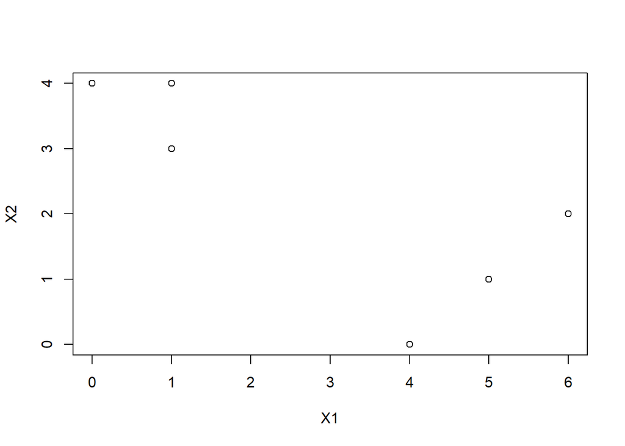

```r
X= cbind(c(1, 1, 0, 5, 6, 4),c(4, 3, 4, 1, 2, 0))
plot(X[,1],X[,2],xlab="X1",ylab="X2")
```

## Exercise 20

Randomly assign a cluster label to each observation. You can use the sample() command in R to do this. Report the cluster labels for each observation.

```r
X = cbind(X,sample.int(2,1))
```

## Exercise 21

Compute the centroid for each cluster.

## Exercise 22

Create a function that calculates the Euclidean distance for two observations.

```r
euclidianDist <- function(X,Y){
  sqrt((X[1]-X[2])**2+(Y[1]-Y[2])**2)
}
```

## Exercise 23

Assign each observation to the centroid to which it is closest, in terms of Euclidean distance. Report the cluster labels for each observation.

## Exercise 24

Repeat 21 and 23 until the answers obtained stop changing.

## Exercise 25

In your plot from 19, color the observations according to the cluster labels obtained.